# SEIR por edad

IW

Apr21

## Matriz de contacto y nuevos contagios

¿Cuanto se contacta cada grupo entre sí y respecto a los demás por cada unidad de tiempo (día)? Sería el factor distanciamiento. La mtriz no es simétrica.

```r
# datos inventados
N = c(100,200,50)
contact_matrix = matrix(c(5,1,1,
                          2,4,4,
                         .5,1,5),3,byrow = T)
colnames(contact_matrix) = rownames(contact_matrix) = c("0-19","20-65","65+")
contact_matrix
```

```
##       0-19 20-65 65+
## 0-19   5.0     1   1
## 20-65  2.0     4   4
## 65+    0.5     1   5
```

Se lee vertical: los niños-adolescentes tienen 5 contactos por día entre sí, 2 contactos con adultos y medio contacto con viejos. Puede ser dinámico también. Debe cumplir que la cantidad de contactos cruzados sea la misma.

```r
# niños con adultos
N[1]*contact_matrix[2,1] == N[2]*contact_matrix[1,2]
```

```
## [1] TRUE
```

```r
# niños con viejos
N[1]*contact_matrix[3,1] == N[3]*contact_matrix[1,3]
```

```
## [1] TRUE
```

```r
# viejos con adultos
N[2]*contact_matrix[3,2] == N[3]*contact_matrix[2,3]
```

```
## [1] TRUE
```

Si la población tendría el mismo peso en cada grupo sería una matriz simétrica. En cada contacto, ¿cual es la probabilidad de contagio? Factor tapaboca, ventilación, etc.

```r
transmission_probability = matrix(.01,3,3)
colnames(transmission_probability) = rownames(transmission_probability) = c("0-19","20-65","65+")
transmission_probability
```

```
##       0-19 20-65  65+
## 0-19  0.01  0.01 0.01
## 20-65 0.01  0.01 0.01
## 65+   0.01  0.01 0.01
```

La matriz tampoco es simétrica de por sí: si se cuidan más los viejos que los niños, la efectividad será distinta para el mismo contacto. Acá se supuso igual para todo contacto.

¿Cómo se generan los nuevos contagios en el SEIR? Por ejemplo para *0-19*, el grupo 1:

```r
# día 0
E = I = e = e_11 = e_12 = e_13 = e_1 = E_1 = c()
S = N
I = c(0,1,0)

# día 1:
beta =  contact_matrix * transmission_probability
# contagios de 0-19 (grupo 1): los niños susceptibles se contactan tantas veces entre sí, pero solo una porción de esos contactos serán contagios, el porcentaje infectado.
  e_11[1] = S[1] * beta[1,1] * I[1]/N[1]
  # Los niños con sus padres
  e_12[1] = S[1] * beta[2,1] * I[2]/N[2]
  # Los niños con sus abueles
  e_13[1] = S[1] * beta[3,1] * I[3]/N[3]
  # El total de nuevos infectados de niños será:
  e_1[1] = e_11[1] + e_12[1] + e_13[1]
# al día siguiente ya hay un niño incubando y en un par de días contagiando a sus pares y abuelos
e_11[1];e_12[1];e_13[1];e_1[1]
```

```
## [1] 0
```

```
## [1] 0.01
```

```
## [1] 0
```

```
## [1] 0.01
```

Puede generalizarse para tener los contagios de los tres grupos:

```r
e = S * (beta %*% I/N)
e_1 == e[1]
```

```
## [1] TRUE
```

El modelo se alimenta de la misma forma, por ejemplo para el grupo 1 de niños:

```r
duracionE=5
E_1[2] = E_1[1] + e_1 - E[1]/duracionE
```

En analogía con la dinámica del $R_0$, se tendría un $R_0$ por cada grupo, que marca el ritmo de contagio de ese grupo específico.

## SEIR por edad

Ejemplo para tres grupos:

```r
seir_ages <- function(dias,
                      duracionE,
                      duracionIi, porc_gr, duracionIg, porc_cr, duracionIc,
                      ifr = c(.03,.03,.03),
                      vacunados = c(0,0,0),
                      contact_matrix,
                      transmission_probability,
                      N = c(1/3,1/3,1/3),
                      zero_cases = c(0,1/45e6*N,0)){

  # cada columna es un grupo
  e = E = S =  i = I = Ii = Ig = Ic = r = R = D = d = U = beta = matrix(0,dias,3)
  # zero cases
  I[1,] = zero_cases
  S[1,] = N - zero_cases
  # efecto vacunas
  porc_gr = porc_gr * (1-vacunados)
  porc_cr = porc_cr * (1-vacunados)

  # seir
  for(t in 2:dias){

    # contagiados según matriz de contacto
    beta       = contact_matrix * transmission_probability
    e[t-1,]    = S[t-1,] * (beta %*% I[t-1,]/N)
    e[t-1,]    =  pmin(e[t-1,], S[t-1,]) # no negativo

    # resto seir
    E[t,]      = E[t-1,] + e[t-1,] - E[t-1,]/duracionE
    i[t,]      = E[t-1,]/duracionE
    Ii[t,]     = Ii[t-1,] + i[t,] - Ii[t-1,]/duracionIi
    Ig[t,]     = Ig[t-1,] - Ig[t-1,]/duracionIg + Ii[t-1,]/duracionIi*porc_gr
    Ic[t,]     = Ic[t-1,] - Ic[t-1,]/duracionIc + Ii[t-1,]/duracionIi*porc_cr
    I[t,]      = Ii[t,] + Ig[t,] + Ic[t,]
    d[t,]      = Ic[t-1,]/duracionIc * ifr/porc_cr # siendo ifr = d[t]/i[t-duracionIi-duracionIc]
    D[t,]      = D[t-1,] + d[t,]
    U[t,]      = U[t-1,] + Ii[t-1,]/duracionIi*(1-porc_gr-porc_cr) + Ig[t-1,]/duracionIg + Ic[t-1,]/duracionIc * (1-ifr/porc_cr)
    R[t,]      = U[t,] + D[t,]
    S[t,]      = N - E[t,] - I[t,] - R[t,]
  }
  results = list(g1 = data.frame(fecha = 1:dias, S=S[,1], E=E[,1], I=I[,1], D=D[,1],R=R[,1]),
                 g2 = data.frame(fecha = 1:dias, S=S[,2], E=E[,2], I=I[,2], D=D[,2],R=R[,2]),
                 g3 = data.frame(fecha = 1:dias, S=S[,3], E=E[,3], I=I[,3], D=D[,3],R=R[,3]))
  return(bind_rows(
            tibble(group = "g1", results[["g1"]]),
            tibble(group = "g2", results[["g2"]]),
            tibble(group = "g3", results[["g3"]]))
         )
}
```

Ejemplos:

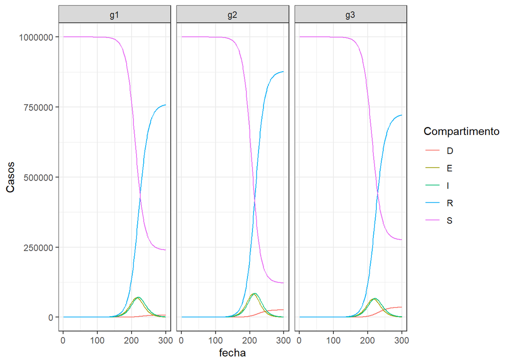

```r
ejemplo <- seir_ages(
                      dias = 300,
                      duracionE = 5,
                      duracionIi=5, porc_gr=.03, duracionIg=5, porc_cr=.01, duracionIc=10,
                      ifr = c(.01,.03,.05),
                      vacunados = c(0,0,0),
                      contact_matrix = contact_matrix,
                      transmission_probability = matrix(.05,3,3),
                      N = c(1e6,1e6,1e6),
                      zero_cases = c(0,1,0))
ejemplo %>%
  pivot_longer(!c(fecha,group), names_to = "Compartimento", values_to = "Casos") %>%
  ggplot(aes(x=fecha, y=Casos, color=Compartimento)) +
  geom_line() + theme_bw() + facet_grid(~group)
```

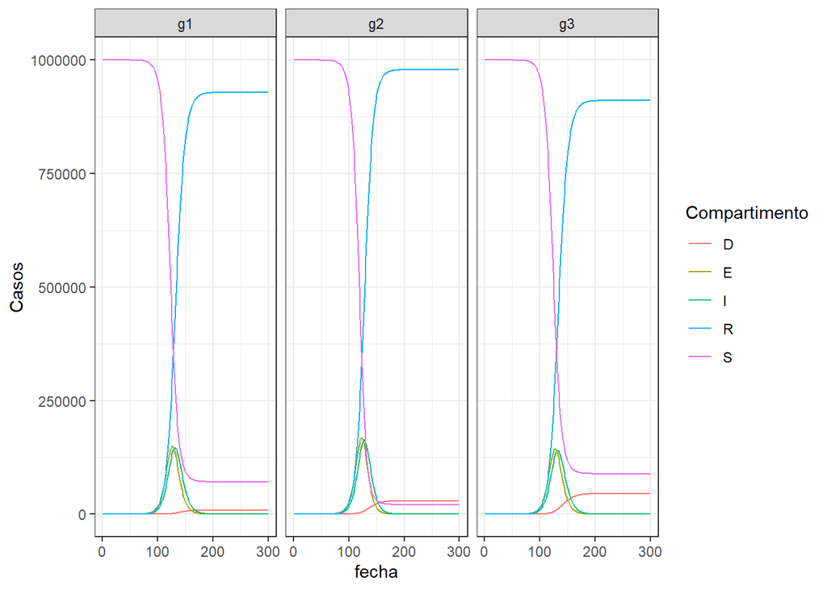

```r
ejemplo2 <- seir_ages(
                      dias = 300,
                      duracionE = 5,
                      duracionIi=5, porc_gr=.03, duracionIg=5, porc_cr=.01, duracionIc=10,
                      ifr = c(.01,.03,.05),
                      vacunados = c(0,0,0),
                      contact_matrix = contact_matrix * 1.5,
                      transmission_probability = matrix(.05,3,3),
                      N = c(1e6,1e6,1e6),
                      zero_cases = c(0,1,0))
ejemplo2 %>%
  pivot_longer(!c(fecha,group), names_to = "Compartimento", values_to = "Casos") %>%
  ggplot(aes(x=fecha, y=Casos, color=Compartimento)) +
  geom_line() + theme_bw() + facet_grid(~group)
```

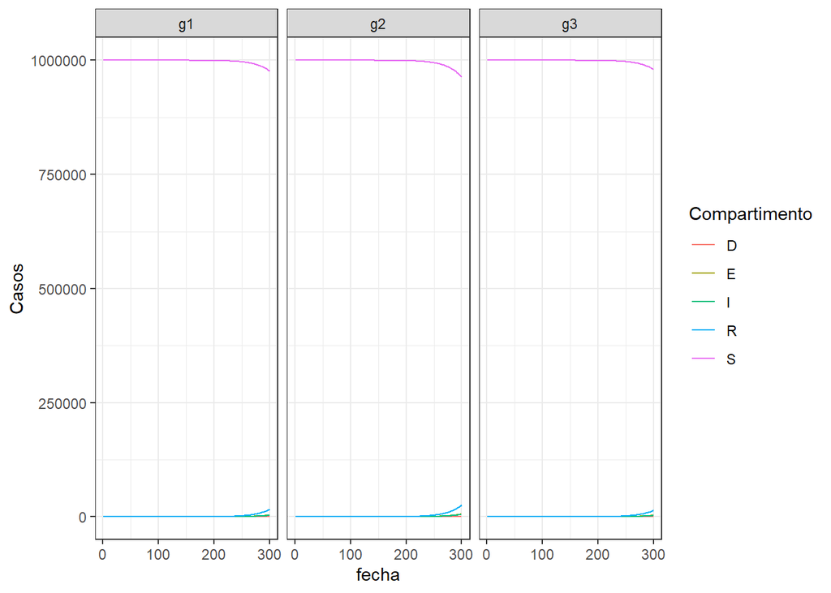

```r
ejemplo3 <- seir_ages(
                      dias = 300,
                      duracionE = 5,
                      duracionIi=5, porc_gr=.03, duracionIg=5, porc_cr=.01, duracionIc=10,
                      ifr = c(.01,.03,.05),
                      vacunados = c(0,0,0),
                      contact_matrix = contact_matrix/2,
                      transmission_probability = matrix(.05,3,3) * 1.5,
                      N = c(1e6,1e6,1e6),
                      zero_cases = c(0,1,0))
ejemplo3 %>%
  pivot_longer(!c(fecha,group), names_to = "Compartimento", values_to = "Casos") %>%
  ggplot(aes(x=fecha, y=Casos, color=Compartimento)) +
  geom_line() + theme_bw() + facet_grid(~group)
```

## matrices de contacto disponibles

Hay de Argentina, tomado de este [proyecto](https://cbdrh.github.io/covoidance/COVOID-age-structured-models.html), recopilado del paper [original](https://journals.plos.org/ploscompbiol/article?id=10.1371/journal.pcbi.1005697), ojo es pre-covid. El paquete permite simular SIR e intervenciones tambien.

```r
library(covoid)
available_contact_matrices() %>% head()
```

```
## [1] "Albania"             "Algeria"             "Andorra"
## [4] "Antigua and Barbuda" "Argentina"           "Armenia"
```

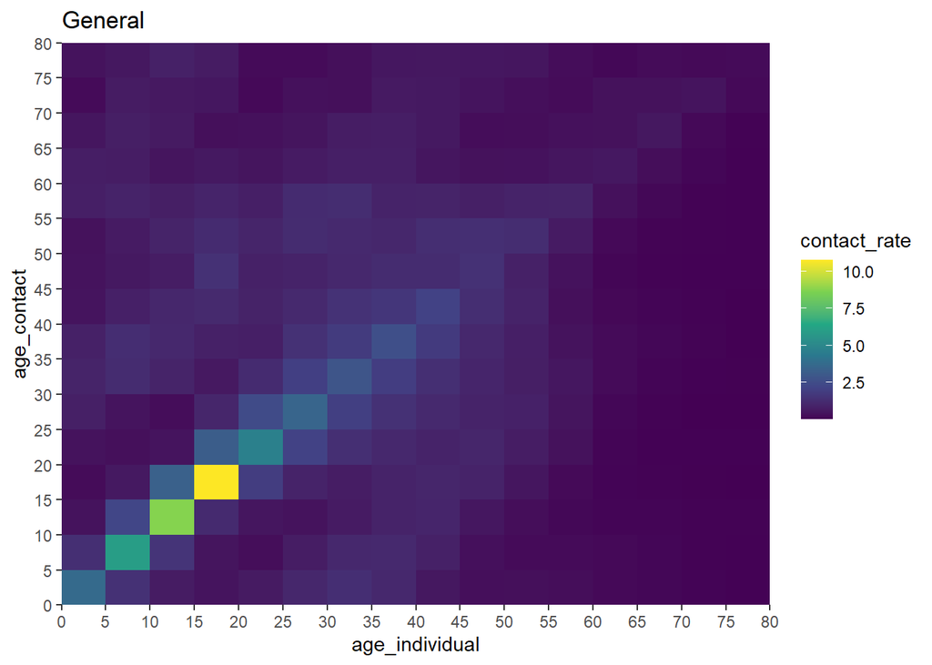

```r
mc_arg <- import_contact_matrix("Argentina","general")
plot(mc_arg) +
    labs(title = "General")
```

## Varios

- dinámica de beta, de vacunas, …
- Uso de categoría *U*, para ver si vuelven a *S*.
- Mortalidad general: tasa standarizada por grupo de edad. Hay solapamiento de causas.
- Referencias:
  - [de referencia](https://cbdrh.github.io/covoidance/COVOID-age-structured-models.html)
  - [coursera](https://www.coursera.org/lecture/building-on-the-sir-model/modelling-age-specific-mixing-pkJnD) muy bueno, el de calibrar puede ser muy útil.
  - [sir con edades](http://sherrytowers.com/2012/12/11/sir-model-with-age-classes/).